# Unit-Weighted Likelihoods & Formal Differential Privacy in LBBNN

Technical Report & Collaborative Vignette (BLS - LBBNN Track 1)

Aliaksandr Hubin & Lars Skaaret-Lund (in collaboration with Terrance D. Savitsky, Matthew R. Williams, Vladislav Beresovsky)

2026-11-16

# 1 Executive Overview & Collaboration Scope

This technical report details the implementation, methodology, and empirical evaluation of **Track 1** of the research collaboration between the **U.S. Bureau of Labor Statistics (BLS)** (Terrance D. Savitsky, Matthew R. Williams, and Vladislav Beresovsky) and the **LBBNN development team** (Aliaksandr Hubin and Lars Skaaret-Lund).

The primary objective of Track 1 is augmenting the `LBBNN` (Latent Binary Bayesian Neural Network) package in R to support two critical statistical operations in official government data production:

1. **Survey-Weighted Imputation & Modeling**: Incorporating unit-indexed survey sampling weights $w_i \propto \pi_i^{-1}$ (where $\pi_i$ is the inclusion probability) into the variational Evidence Lower Bound (ELBO) objective. This allows the neural network to approximate the true population likelihood from an informatively sampled survey, eliminating bias in missing data imputation and domain estimation.
2. **Formally Private Synthetic Data Generation**: Implementing the two-pass risk-weighted pseudo-posterior mechanism (Savitsky, Williams & Hu, 2022). In Pass 1, unweighted model posterior draws are used to extract record-level log-likelihood contributions and quantify disclosure risk. Symmetrically, record-specific privacy weights $\alpha_i \in [0, 1]$ calibrate high-risk outliers during Pass 2, yielding synthetic microdata equipped with a mathematically provable local $(\epsilon, \delta)$-probabilistic differential privacy (PDP) guarantee without degrading utility for safe observations.

```r
library(LBBNN)
library(torch)
library(ggplot2)
library(gridExtra)

# Ensure reproducibility
set.seed(2026)
torch::torch_manual_seed(2026)
```

# 2 Mathematical Framework

## 2.1 Variational Inference with Observation Weights

### 2.1.1 From Standard Posteriors to the Unit-Weighted Pseudo-Posterior

Let $\mathbf{y} = (y_1, \dots, y_n)^\top \in \mathcal{Y}^n$ denote an observed dataset with associated auxiliary covariates $\mathbf{X} = (\mathbf{x}_1, \dots, \mathbf{x}_n)^\top$. In standard Bayesian inference, model parameters $\theta \in \Theta$ are endowed with a prior $p(\theta)$, and conditioning on the data yields the exact posterior distribution:

$$p(\theta \mid \mathbf{y}) =
\frac{p(\theta) \prod_{i=1}^n f(y_i \mid \mathbf{x}_i,
\theta)}{\int_{\Theta} p(\theta) \prod_{i=1}^n f(y_i \mid \mathbf{x}_i,
\theta) \, d\theta}$$

In complex survey sampling and privacy-preserving synthesis, individual observations do not contribute equally to the inferential target. To account for unequal survey selection probabilities or heterogeneous disclosure risks, we equip each observation $i$ with a non-negative unit weight $u_i \ge 0$, defining the **unit-weighted pseudo-posterior distribution** (Savitsky & Toth, 2016; Bhattacharya et al., 2019):

$$p_{\mathbf{u}}(\theta \mid \mathbf{y}) =
\frac{p(\theta) \prod_{i=1}^n f(y_i \mid \mathbf{x}_i,
\theta)^{u_i}}{Z_{\mathbf{u}}}, \qquad Z_{\mathbf{u}} = \int_{\Theta}
p(\theta) \prod_{i=1}^n f(y_i \mid \mathbf{x}_i, \theta)^{u_i} \,
d\theta$$

In Mean-Field Variational Inference (MFVI) for LBBNNs, the intractable pseudo-posterior $p_{\mathbf{u}}(\theta \mid \mathbf{y})$ is approximated by a tractable variational family $q(\theta) = q(\theta, \gamma)$. To find the optimal variational parameters, we minimize the Kullback-Leibler (KL) divergence from $q(\theta)$ to $p_{\mathbf{u}}(\theta \mid \mathbf{y})$:

$$\begin{aligned}
\text{KL}\big(q(\theta) \parallel p_{\mathbf{u}}(\theta \mid
\mathbf{y})\big) &= \mathbb{E}_{q(\theta)}\left[\log q(\theta) -
\log p_{\mathbf{u}}(\theta \mid \mathbf{y})\right] \\
&= \mathbb{E}_{q(\theta)}[\log q(\theta)] -
\mathbb{E}_{q(\theta)}\left[\log p(\theta) + \sum_{i=1}^n u_i \log f(y_i
\mid \mathbf{x}_i, \theta) - \log Z_{\mathbf{u}}\right] \\
&= \text{KL}\big(q(\theta) \parallel p(\theta)\big) - \sum_{i=1}^n
u_i \, \mathbb{E}_{q(\theta)}\!\left[\log f(y_i \mid \mathbf{x}_i,
\theta)\right] + \log Z_{\mathbf{u}}
\end{aligned}$$

Because the marginal normalizing constant $Z_{\mathbf{u}}$ does not depend on the variational distribution $q(\theta)$, minimizing $\text{KL}\big(q(\theta) \parallel p_{\mathbf{u}}(\theta \mid \mathbf{y})\big)$ is mathematically equivalent to maximizing the **unit-weighted Evidence Lower Bound (ELBO)**:

$$\text{ELBO}(q; \mathbf{u}) =
\sum_{i=1}^n u_i \, \mathbb{E}_{q(\theta)}\!\left[\log f(y_i \mid
\mathbf{x}_i, \theta)\right] - \text{KL}\big(q(\theta) \parallel
p(\theta)\big)$$

### 2.1.2 Mini-Batch Alignment & ELBO Scaling

When optimizing the ELBO via stochastic gradient descent across $M$ mini-batches with batch size $B$, the mini-batch objective must maintain exact unit-level alignment between each covariate vector $\mathbf{x}_i$, outcome $y_i$, and its assigned weight $u_i$, while properly scaling the likelihood relative to the prior regularization penalty:

$$\text{ELBO}_{\text{batch}}(q;
\mathbf{u}) = \sum_{i \in \text{batch}} u_i \, \log f(y_i \mid
\mathbf{x}_i, \theta) - \frac{1}{M} \text{KL}\big(q(\theta) \parallel
p(\theta)\big)$$

The surrogate mini-batch training loss minimized during back-propagation is the negative weighted ELBO:

$$\text{Loss}_{\text{batch}}(q;
\mathbf{u}) = -\text{ELBO}_{\text{batch}}(q; \mathbf{u}) = \sum_{i \in
\text{batch}} u_i \left( -\log f(y_i \mid \mathbf{x}_i, \theta) \right)
+ \frac{1}{M} \text{KL}\big(q(\theta) \parallel
p(\theta)\big)$$

When $u_i = 1$ for all $i = 1, \dots, n$, this formulation is **100% numerically identical** to standard unweighted variational training.

### 2.1.3 Survey Weight Normalization vs. Privacy Weight Scaling

A critical operational distinction exists between **survey sampling weights** ($w_i$) and **differential privacy weights** ($\alpha_i$):

1. **Survey Sampling Weights ($w_i = \pi_i^{-1}$)**: In design-based survey inference, raw inverse-probability weights $w_i = 1/\pi_i$ estimate population totals and satisfy $\sum_{i=1}^n w_i \approx N_{\text{pop}}$, where $N_{\text{pop}} \gg n$. If raw weights were inserted directly into the ELBO, the weighted log-likelihood term would scale with $N_{\text{pop}}$, overpowering the prior $\text{KL}\big(q(\theta) \parallel p(\theta)\big)$ regularization penalty by a factor of $N_{\text{pop}} / n$. Following Savitsky & Toth (2016), we normalize survey weights to sum to the observed sample size $n$:
   $$\tilde{w}_i = w_i \times \frac{n}{\sum_{j=1}^n
   w_j}$$
   This normalization ensures the effective sample size in the variational pseudo-posterior matches $n$, preserving the intended balance between data evidence and prior regularization. In `get_dataloaders()`, this is activated by setting `normalize_weights = TRUE`.
2. **Differential Privacy Weights ($\alpha_i \in [0, 1]$)**: In the two-pass privacy mechanism (Savitsky, Williams & Hu, 2022), the risk weights $\alpha_i \in [0, 1]$ measure record safety, where $\alpha_i \to 0$ for high-risk outliers and $\alpha_i \approx 1$ for typical observations. Here, $\sum_{i=1}^n \alpha_i \le n$. These weights are **intentionally left unnormalized** (`normalize_weights = FALSE`, the default). Under-weighting high-risk records tempers their influence on the posterior, naturally shrinking parameter estimates toward the prior distribution in regions of high disclosure risk.

### 2.1.4 Full Error Variance Specification & Protection Against Cold/Warm Posteriors

A fundamental challenge in Bayesian deep learning is the **cold posterior / cold prior problem** (Wenzel et al., 2020), wherein misspecifying the likelihood scale introduces an unintended temperature $T \neq 1$:

$$\mathcal{L}_{\text{ELBO}}(q) =
\frac{1}{T} \sum_{i=1}^n u_i \, \mathbb{E}_{q(\theta)}\!\left[\log f(y_i
\mid \mathbf{x}_i, \theta)\right] - \text{KL}\big(q(\theta) \parallel
p(\theta)\big)$$

In Gaussian regression with observation model $y_i \mid \mathbf{x}_i, \theta \sim \mathcal{N}\big(\mu_\theta(\mathbf{x}_i), \sigma^2\big)$, the exact pointwise log-likelihood is:

$$\log f(y_i \mid \mathbf{x}_i, \theta,
\sigma^2) = -\frac{1}{2}\log(2\pi\sigma^2) - \frac{\big(y_i -
\mu_\theta(\mathbf{x}_i)\big)^2}{2\sigma^2}$$

Many conventional neural network implementations replace this exact Gaussian density with an unscaled sum of squared errors $-\frac{1}{2}\sum_i (y_i - \mu_i)^2$, implicitly fixing $\sigma^2 = 1.0$ (precision $\tau = 1.0$). Whenever the true noise variance differs from unity (for example, $\sigma = 0.40 \implies \sigma^2 = 0.16$ in Example 1), using unscaled squared error dampens the data log-likelihood by a factor of $\sigma^2 = 0.16$ relative to the prior KL divergence:

$$\frac{1}{2} (y_i - \mu_i)^2 = 0.16
\times \left[ \frac{(y_i - \mu_i)^2}{2 \times 0.16} \right]$$

Furthermore, in the Two-Pass Differential Privacy mechanism, each unit’s record sensitivity:

$$f_i = \max_{s \in \{1,\dots,S\}} \left|
\log f(y_i \mid \mathbf{x}_i, \theta^{(s)}, \sigma^2)
\right|$$

directly depends on the residual scale $\sigma^2$. If $\sigma^2$ is misspecified, sensitivities are measured on an arbitrary scale, invalidating the empirical privacy guarantee $\epsilon_{\mathbf{y}} = 2\Delta_{\alpha, \mathbf{y}}$. To guarantee full probabilistic calibration, `lbbnn_net()` accepts an explicit `sigma` argument (or automatically calibrates $\hat{\sigma}$ from training residuals in `fit_dp_lbbnn()`), evaluating the exact negative log-likelihood:

$$\text{NLL}_i =
\frac{1}{2}\log(2\pi\sigma^2) + \frac{(y_i -
\mu_\theta(\mathbf{x}_i))^2}{2\sigma^2}$$

This guarantees that variational training operates at the exact Bayesian temperature $T = 1.0$, protecting edge selection decisions from cold-posterior bias and grounding privacy sensitivities in the true data distribution.

### 2.1.5 Domain-Level Estimation & Observation Error De-Noising

Official statistical agencies routinely require domain totals and domain means across sub-populations (e.g., industry sectors or geographic subdivisions) rather than a single global population mean. Let $\mathbf{G} \in \mathbb{R}^{n \times D_{\text{dom}}}$ denote a binary or fractional domain membership matrix, where $G_{i,d} = 1$ if unit $i$ belongs to domain $d \in \{1, \dots, D_{\text{dom}}\}$.

The design-weighted domain mean and total are given by:

$$\hat{\bar{Y}}_d = \frac{\sum_{i=1}^n w_i
G_{i,d} y_i}{\sum_{i=1}^n w_i G_{i,d}}, \qquad \hat{Y}_{\text{total}, d}
= \sum_{i=1}^n w_i G_{i,d} y_i$$

In `LBBNN`, we combine the design weights with posterior draws of the regression surface $\mu_{\theta^{(s)}}(\mathbf{x}_i)$ to form model-assisted domain predictions:

$$\hat{\bar{Y}}_d^{\text{BNN}(s)} =
\frac{\sum_{i=1}^n w_i G_{i,d} \hat{\mu}_i^{(s)}}{\sum_{i=1}^n w_i
G_{i,d}}$$

**Model-Assisted Conditional Expectation**: While spike-and-slab edge selection prunes uninformative noise covariates (as demonstrated empirically with noise features $X_3, X_4$ in Section 3), additive unit-level observation error $\varepsilon_i \sim \mathcal{N}(0, \sigma^2)$ in $y_i = \mu(\mathbf{x}_i) + \varepsilon_i$ cannot be isolated from unobserved unit heterogeneity in cross-sectional data without repeated measurements. However, by evaluating the posterior conditional expectation $\hat{\mu}_i^{(s)} = \mathbb{E}[Y_i \mid \mathbf{x}_i, \theta^{(s)}] = \mu_{\theta^{(s)}}(\mathbf{x}_i)$ (`type = "conditional_mean"`) rather than drawing noisy predictive samples $\tilde{y}_i^{(s)} = \mu_{\theta^{(s)}}(\mathbf{x}_i) + \varepsilon_i^{(s)}$ (`type = "predictive"`), `predict_domains_lbbnn()` avoids adding posterior predictive simulation noise, yielding a smooth estimate of the underlying regression surface.

### 2.1.6 Bayesian Imputation for Missing Survey Responses ($y_i = \text{NA}$)

Item non-response is pervasive in survey sampling. In `LBBNN`, we partition sample units into observed units $S_{\text{obs}} = \{i : \text{!is.na}(y_i)\}$ and missing units $S_{\text{mis}} = \{i : \text{is.na}(y_i)\}$. During variational optimization (`get_dataloaders(..., allow_missing = TRUE)`), the weighted log-likelihood is evaluated over $i \in S_{\text{obs}}$.

Downstream, `impute_response_lbbnn()` generates multiple imputation posterior draws:

$$\tilde{y}_i^{(s)} \sim
\mathcal{N}\big(\mu_{\theta^{(s)}}(\mathbf{x}_i), \sigma^2\big), \qquad
i \in S_{\text{mis}}, \quad s \in \{1, \dots, S\}$$

These draws capture both parameter uncertainty (variation in $\theta^{(s)} \sim q(\theta)$) and residual sampling uncertainty (calibrated $\sigma^2$).

### 2.1.7 Correcting Pseudo-Posterior Variance Deficits via Dirichlet Bayesian Bootstrap

Because the survey-weighted pseudo-posterior conditions on the observed sample $S$ as if it were fixed, naive pseudo-posterior credible intervals underestimate the true finite-population sampling variance generated by the survey design. Following Savitsky & Toth (2016), we calibrate posterior intervals by sampling flat Dirichlet perturbations for each draw $s \in \{1, \dots, S\}$:

$$\boldsymbol{\xi}^{(s)} =
\big(\xi_1^{(s)}, \dots, \xi_n^{(s)}\big) \sim \text{Dirichlet}(1,
\dots, 1)$$

implemented via normalized Exponential draws: $\xi_i^{(s)} = E_i^{(s)} / \sum_{j=1}^n E_j^{(s)}$ with $E_i^{(s)} \stackrel{\text{i.i.d.}}{\sim} \text{Exp}(1)$. Multiplying these Dirichlet perturbations into the survey weights yields the calibrated domain estimator:

$$\hat{\bar{Y}}_d^{(s)} =
\frac{\sum_{i=1}^n \xi_i^{(s)} w_i G_{i,d} y_i^{(s)}}{\sum_{i=1}^n
\xi_i^{(s)} w_i G_{i,d}}$$

In `predict_domains_lbbnn(..., dirichlet_uq = TRUE)` and `hajek_estimate(..., dirichlet_uq = TRUE)`, this Bayesian bootstrap perturbation restores exact frequentist coverage under complex survey sampling.

## 2.2 Two-Stage Differential Privacy Calibration (Savitsky, Oct 29, 2026)

In official microdata synthesis, we evaluate unit-level log-likelihood sensitivities across posterior parameter draws:

$$f_i = \max_{s \in \{1, \dots, S\}}
\left| \log f(y_i \mid \mathbf{x}_i, \theta^{(s)}) \right|, \qquad
f_{\min} = \min_{j=1, \dots, n} f_j, \quad f_{\max} = \max_{j=1, \dots,
n} f_j$$

Following Savitsky (Oct 29, 2026, *Privacy Weight Normalization and Second-Stage Reweighting Strategies in Asymptotic Differential Privacy*, `re_weight4-3.pdf`), privacy weights $\alpha_i$ are calibrated in two modular stages. Crucially, Stage 1 normalization operates **directly on sensitivities $f_i$** via $1 - \tilde{f}_i$:

### 2.2.1 Stage 1: Initial Privacy Weight Normalization on $f_i$ (`stage1_method`)

1. **Method 1 (`"linear"`) — Direct Linear Min-Max on $f_i$ (Savitsky et al., 2022, Eq. 4–5)**:
   $$\tilde{f}_i = \frac{f_i -
   f_{\min}}{f_{\max} - f_{\min}} \in [0, 1], \qquad \alpha_i^{\text{lin}}
   = \text{clip}_{[0, 1]}\!\left(c \cdot (1 - \tilde{f}_i) + g\right) =
   \text{clip}_{[0, 1]}\!\left(c \left(\frac{f_{\max} - f_i}{f_{\max} -
   f_{\min}}\right) + g\right)$$
   where $c \in (0, 1]$ controls scaling and $g \ge 0$ allows a baseline shift.

   *Remark 1 (Direct $1 - \tilde{f}_i$ vs. Reciprocal Transformation $1/f_i$, Eq. 8–9)*: Normalizing reciprocal sensitivities $\tilde{\alpha}_i = 1/f_i$ yields:
   $$\alpha_i^{\text{recip}} =
   \left(\frac{f_{\min}}{f_i}\right) \alpha_i^{\text{lin}} <
   \alpha_i^{\text{lin}} \quad \forall f_i \in (f_{\min},
   f_{\max})$$
   which introduces an aggressive hyperbolic penalty $(f_{\min}/f_i)$ that severely attenuates weights and collapses all intermediate observations if $f_{\min} \to 0$. By contrast, direct normalization on $f_i$ preserves weight mass across the distribution. Although the unit contribution $\alpha_i^{\text{lin}} f_i$ is parabolic in $f_i$ with an interior peak at $f_{\max}/2$, this peak is strictly bounded: $\max_i \alpha_i^{\text{lin}} f_i \le \frac{c}{4} f_{\max}$, which can be capped in Stage 2.
2. **Method 2 (`"percentile"`) — Percentile Deficit Truncation on $f_i$ (Eq. 10–12)**: Let $q_{p_L}(f) < q_{p_R}(f)$ denote empirical quantiles of $f_i$ at $0 < p_L < p_R < 1$ (default $p_L = 0.05, p_R = 0.95$):
   $$\tilde{f}_i^{\text{pct}} = \frac{f_i -
   q_{p_L}(f)}{q_{p_R}(f) - q_{p_L}(f)}, \qquad \alpha_i^{\text{pct}} =
   \min\!\left(1, \, \max\!\left(0, \, 1 -
   \tilde{f}_i^{\text{pct}}\right)\right) = \min\!\left(1, \,
   \max\!\left(0, \, \frac{q_{p_R}(f) - f_i}{q_{p_R}(f) -
   q_{p_L}(f)}\right)\right)$$
   - *Low Sensitivity Inliers* ($f_i \le q_{p_L}(f)$): Receive full weight $\alpha_i^{\text{pct}} = 1$.
   - *Intermediate Units* ($q_{p_L}(f) < f_i < q_{p_R}(f)$): Decay linearly in $(0, 1)$.
   - *High Sensitivity Outliers* ($f_i \ge q_{p_R}(f)$): Hard-truncated to $\alpha_i^{\text{pct}} = 0$. This boosts the effective sample size $\sum_{i=1}^n \alpha_i^{\text{pct}}$, but creates a privacy deficit for units near $q_{p_L}(f)$ that is subsequently addressed in Stage 2.
3. **Method 3 (`"target_clip"`) — Target Ratio Clipping ($\Delta_{i,\text{goal}}$ Ratio Clipping, Eq. 13)**: Given sensitivity goal $\Delta_{i,\text{goal}} > 0$ (defaulting to $M_{\text{thresh}}$):
   $$\alpha_i^{\text{clip}} = \min\!\left(1, \,
   \frac{\Delta_{i,\text{goal}}}{f_i}\right)$$
   *Properties (Proposition 1 of Savitsky, 2026)*: Guarantees exact sensitivity control $\alpha_i^{\text{clip}} f_i = \min(f_i, \Delta_{\text{goal}}) \le \Delta_{\text{goal}}$ by construction, leaving all low-sensitivity records ($f_i \le \Delta_{\text{goal}}$) untouched at $\alpha_i^{\text{clip}} = 1$.

### 2.2.2 Stage 2: Second-Stage Reweighting Schemes (`stage2_method`)

Given Stage 1 weights $\boldsymbol{\alpha}$ and sensitivity threshold $M_{\text{thresh}} > 0$, enforce $\alpha_i^* f_i \le M_{\text{thresh}}$:

1. **Scheme 1 (`"hard_trunc"`) — Hard Threshold Truncation (Eq. 16)**:
   $$\alpha_i^{\text{trunc}} = \alpha_i \,
   \mathbb{I}(\alpha_i f_i \le M_{\text{thresh}})$$
   Single-pass post-hoc zeroing of records exceeding $M_{\text{thresh}}$. Discards privacy slack ($M_{\text{thresh}} - \alpha_i f_i$).
2. **Scheme 2 (`"vector_upscale"`) — Vector-Weighted Upward Rescaling (Savitsky, Hu, & Williams, 2020, Eq. 17–18)**:
   $$\alpha_i^{\text{vec}}
   = \min\!\left(1, \, \alpha_i \cdot \frac{M_{\text{thresh}}}{\alpha_i
   f_i}\right) = \min\!\left(1, \,
   \frac{M_{\text{thresh}}}{f_i}\right)$$
   *Properties (Proposition 2 of Savitsky, 2026)*: Pointwise dominates hard truncation ($\alpha_i^{\text{vec}} \ge \alpha_i^{\text{trunc}}$ for all $i$), maximizing Fisher information $\mathcal{I}_{\boldsymbol{\alpha}^{\text{vec}}}(\theta) \succeq \mathcal{I}_{\boldsymbol{\alpha}^{\text{trunc}}}(\theta)$ in the Loewner partial order. *Multi-Pass Geometry*: Because upward rescaling shifts the pseudo-posterior $\xi_{\boldsymbol{\alpha}^{\text{vec}}}(\theta \mid D)$, `fit_dp_lbbnn()` executes Pass 3 targeting $\xi_{\boldsymbol{\alpha}^{\text{vec}}}$ to draw updated parameters and guarantee bound verification.

### 2.2.3 Likelihood Exponent Mass ESS & Algebraic Cancellation

In differential privacy pseudo-posterior estimation, $\alpha_i^* \in [0, 1]$ acts as an observation-specific power exponent in the pseudo-likelihood. Thus, the effective sample size is defined as the total retained likelihood information mass:
$$\text{ESS} = \sum_{i=1}^n
\alpha_i^* \in [0, n]$$
This differs fundamentally from Kish’s (1965) survey design design-effect ESS $\frac{(\sum w_i)^2}{\sum w_i^2}$, which measures variance inflation caused by unequal probability sampling weights.

Furthermore, under Stage 2 vector upward rescaling:
$$\alpha_i^{\text{vec}} = \min\!\left(1, \,
\alpha_i^{(1)} \cdot \frac{M_{\text{thresh}}}{\alpha_i^{(1)} f_i}\right)
= \min\!\left(1, \, \frac{M_{\text{thresh}}}{f_i}\right)$$
whenever $\alpha_i^{(1)} > 0$, the initial weight $\alpha_i^{(1)}$ algebraically cancels. Consequently, `target_clip + vector_upscale`, `target_clip + hard_trunc`, and `linear + vector_upscale` converge to the exact same weight profile on any dataset where $\alpha_i^{(1)} > 0$ for all records.

```
                     Raw Data (X, y)
                            v
             +------------------------------+
             |    Pass 1: Unweighted Fit    |
             +--------------+---------------+
                            v
         Evaluate S x n Log-Likelihood Matrix L^(1)
                            v
         Record Sensitivity: f_i = max_s |L_{s, i}^(1)|
                            v
         Stage 1: linear / percentile / target_clip
                            v
         Stage 2: hard_trunc / vector_upscale
                            v
             +------------------------------+
             |   Pass 2: alpha-Weighted Fit |
             +--------------+---------------+
                            v  (If vector_upscale: Pass 3 on updated geometry)
             +------------------------------+
             |   Pass 3: Final alpha Fit    |
             +--------------+---------------+
                            v
       Local DP Guarantee: epsilon_y = 2 * Delta_{alpha, y} <= 2 * M_thresh
                            v
       Posterior Predictive Synthesis with Calibrated Noise sigma_hat
```

# 3 Example 1: Survey-Weighted Imputation Under Informative Sampling

## 3.1 Simulating an Informatively Sampled Population

In complex survey sampling, observations are drawn with unequal inclusion probabilities $\pi_i = \mathbb{P}(i \in S)$. When inclusion depends directly on the outcome variable $Y_i$, sampling is **informative**: sample units have positively biased residuals $\mathbb{E}[\varepsilon_i \mid i \in S] > 0$, causing standard unweighted models to produce biased parameter estimates and skewed imputations.

We simulate a finite population of $N = 2,000$ individuals where outcome $Y$ depends non-linearly on active predictors $X_1$ and $X_2$, with independent Gaussian noise predictors $X_3$ and $X_4$:

$$Y_i = 2.0 X_{1i} + 1.5 \sin(\pi X_{2i})
+ 0.8 X_{1i} X_{2i} + \varepsilon_i, \quad \varepsilon_i \sim
\mathcal{N}(0, 0.4^2)$$

The probability of inclusion in the sample is heavily skewed towards higher values of $Y$:

$$\pi_i = \sigma\big(-1.0 + 1.2 Y_i\big),
\qquad \sigma(z) = \frac{1}{1 + e^{-z}}$$

```r
# Generate population
N_pop <- 2000
x1_pop <- rnorm(N_pop, 0, 1)
x2_pop <- runif(N_pop, -1, 1)
x3_pop <- rnorm(N_pop, 0, 1) # noise
x4_pop <- rnorm(N_pop, 0, 1) # noise

y_pop <- 2.0 * x1_pop + 1.5 * sin(pi * x2_pop) + 0.8 * x1_pop * x2_pop + rnorm(N_pop, 0, 0.4)
true_pop_mean <- mean(y_pop)

# Informative sampling mechanism
pi_inc <- plogis(-1.0 + 1.2 * y_pop)
pi_inc <- pmax(pi_inc, 0.05) # bound away from zero

# Draw sample
in_sample <- rbinom(N_pop, 1, pi_inc) == 1
n_smp <- sum(in_sample)

sample_df <- data.frame(
  x1 = x1_pop[in_sample],
  x2 = x2_pop[in_sample],
  x3 = x3_pop[in_sample],
  x4 = x4_pop[in_sample],
  y  = y_pop[in_sample]
)

# Survey sampling design weights
weights_survey <- 1 / pi_inc[in_sample]

cat(sprintf("Population Size: %d | True Pop Mean Y: %.3f\n", N_pop, true_pop_mean))
```

```
## Population Size: 2000 | True Pop Mean Y: -0.000
```

```r
cat(sprintf("Sample Size: %d | Unweighted Sample Mean: %.3f (Bias: +%.3f)\n",
            n_smp, mean(sample_df$y), mean(sample_df$y) - true_pop_mean))
```

```
## Sample Size: 737 | Unweighted Sample Mean: 2.009 (Bias: +2.009)
```

```r
cat(sprintf("Hajek Weighted Sample Mean: %.3f (Bias: %+.3f)\n",
            sum(weights_survey * sample_df$y) / sum(weights_survey),
            sum(weights_survey * sample_df$y) / sum(weights_survey) - true_pop_mean))
```

```
## Hajek Weighted Sample Mean: 0.271 (Bias: +0.272)
```

## 3.2 Fitting Unweighted vs. Survey-Weighted LBBNN

While the classical design-based **Hájek estimator** $\hat{\bar{Y}}_{\text{Hájek}} = \frac{\sum_{i \in S} w_i y_i}{\sum_{i \in S} w_i}$ reduces mean bias, it provides only a single scalar estimate and **cannot impute** missing values $y_i$ for non-sampled units ($i \notin S$).

To impute missing values across the population, we fit:

1. **Unweighted LBBNN**: Fits directly on the biased sample data.
2. **Survey-Weighted LBBNN**: Weights each unit’s log-likelihood by sample-size normalized weights $\tilde{w}_i = w_i \cdot (n / \sum w_i)$ via `normalize_weights = TRUE` (Savitsky & Toth, 2016).

```r
# Model specification with calibrated observation noise sigma = 0.40
spec_survey <- list(
  problem_type = "regression",
  sizes = c(4, 16, 16, 1),
  prior = c(0.2, 0.2, 0.2), # Prior inclusion probabilities
  std = c(1.0, 1.0, 1.0),
  inclusion_inits = "balanced",
  input_skip = TRUE,
  flow = FALSE,
  sigma = 0.40, # Calibrated observation standard deviation (DGP sigma = 0.4)
  device = "cpu"
)

# 1. Dataloader for Unweighted Model
dl_unweighted <- get_dataloaders(
  dataset = sample_df,
  train_proportion = 1.0,
  train_batch_size = 64,
  test_batch_size = 64,
  standardize = FALSE,
  shuffle_train = TRUE,
  normalize_weights = FALSE,
  seed = 42
)

# 2. Dataloader for Survey-Weighted Model (with sample-size normalization)
dl_weighted <- get_dataloaders(
  dataset = sample_df,
  train_proportion = 1.0,
  train_batch_size = 64,
  test_batch_size = 64,
  standardize = FALSE,
  shuffle_train = TRUE,
  weights = weights_survey,
  normalize_weights = TRUE, # Savitsky & Toth (2016)
  seed = 42
)

# Train Unweighted Model
m_unweighted <- do.call(lbbnn_net, spec_survey)
train_unweighted <- train_lbbnn(
  epochs = 200,
  LBBNN = m_unweighted,
  lr = 0.02,
  train_dl = dl_unweighted$train_loader,
  verbose = FALSE
)

# Train Survey-Weighted Model
m_weighted <- do.call(lbbnn_net, spec_survey)
train_weighted <- train_lbbnn(
  epochs = 200,
  LBBNN = m_weighted,
  lr = 0.02,
  train_dl = dl_weighted$train_loader,
  verbose = FALSE
)
```

## 3.3 Sparse Graph Selection & Inclusion Probabilities

The normalization $\tilde{w}_i = w_i \frac{n}{\sum w_j}$ is critical for Table 1: without sample-size normalization, raw inverse-probability weights ($\sum w_i \approx 2,000 \gg n = 737$) would inflate the log-likelihood by a factor of $2.7\times$, overpowering the spike-and-slab KL prior penalty and causing false-positive inclusion of the noise variables $X_3, X_4$.

```r
var_summary <- summary(m_weighted)
```

```
## Summary of lbbnn_net object:
## -----------------------------------
## Shows the number of times each variable was included from each layer
## -----------------------------------
## Then the average inclusion probability for each input from each layer
## -----------------------------------
## The final column shows the average inclusion probability across all layers
## -----------------------------------
##    L0 L1 L2    a0    a1    a2 a_avg
## x0  1  7  1 0.269 0.552 0.999 0.429
## x1  1  2  1 0.237 0.281 0.999 0.282
## x2  0  0  0 0.121 0.128 0.018 0.122
## x3  0  0  0 0.123 0.122 0.130 0.122
## The model took 37.747 seconds to train, using cpu
```

```r
var_sel_tbl <- data.frame(
  Covariate = c("x1 (Active Linear)", "x2 (Active Non-linear)", "x3 (Noise)", "x4 (Noise)"),
  Output_Paths = var_summary$L2,
  Layer1_Inclusion = var_summary$a0,
  Layer2_Inclusion = var_summary$a1,
  Output_Inclusion = var_summary$a2,
  Mean_Inclusion   = var_summary$a_avg,
  MPM_Selected     = ifelse(var_summary$a2 > 0.5, "Selected (Active)", "Pruned (Zeroed)"),
  row.names = NULL
)

knitr::kable(
  var_sel_tbl,
  digits = 3,
  row.names = FALSE,
  col.names = c("Covariate", "Out Paths", "L1 Incl.", "L2 Incl.", "Out Incl.", "Mean Incl.", "MPM Status"),
  caption = "Variational Inclusion Probabilities and Median Probability Model (MPM) Selection Under Survey Weighting"
)
```

Variational Inclusion Probabilities and Median Probability Model (MPM) Selection Under Survey Weighting

| Covariate | Out Paths | L1 Incl. | L2 Incl. | Out Incl. | Mean Incl. | MPM Status |
| --- | --- | --- | --- | --- | --- | --- |
| x1 (Active Linear) | 1 | 0.269 | 0.552 | 0.999 | 0.429 | Selected (Active) |
| x2 (Active Non-linear) | 1 | 0.237 | 0.281 | 0.999 | 0.282 | Selected (Active) |
| x3 (Noise) | 0 | 0.121 | 0.128 | 0.018 | 0.122 | Pruned (Zeroed) |
| x4 (Noise) | 0 | 0.123 | 0.122 | 0.130 | 0.122 | Pruned (Zeroed) |

As demonstrated, both active predictors $X_1$ and $X_2$ achieve near-unity output inclusion ($a_2 \approx 0.999$) with active output paths ($L_2 = 1$). In contrast, noise features $X_3$ and $X_4$ have zero output paths ($L_2 = 0$) and are cleanly pruned to $a_2 \le 0.130$.

## 3.4 Evaluation on the True Population

We predict across all $N = 2,000$ population units to evaluate imputation accuracy, comparing full Bayesian Model Averaging (BMA) and the sparse Median Probability Model (MPM):

```r
pop_x_df <- data.frame(x1 = x1_pop, x2 = x2_pop, x3 = x3_pop, x4 = x4_pop)

preds_unw_bma <- predict(m_unweighted, newdata = pop_x_df, draws = 50, mpm = FALSE)
preds_w_bma   <- predict(m_weighted, newdata = pop_x_df, draws = 50, mpm = FALSE)
preds_unw_mpm <- predict(m_unweighted, newdata = pop_x_df, draws = 50, mpm = TRUE)
preds_w_mpm   <- predict(m_weighted, newdata = pop_x_df, draws = 50, mpm = TRUE)

y_hat_unw_bma <- as.numeric(preds_unw_bma$mean(dim = 1)$cpu())
y_hat_w_bma   <- as.numeric(preds_w_bma$mean(dim = 1)$cpu())
y_hat_unw_mpm <- as.numeric(preds_unw_mpm$mean(dim = 1)$cpu())
y_hat_w_mpm   <- as.numeric(preds_w_mpm$mean(dim = 1)$cpu())

y_naive_mean <- mean(sample_df$y)
y_hajek_mean <- sum(weights_survey * sample_df$y) / sum(weights_survey)

rmse_naive   <- sqrt(mean((y_pop - y_naive_mean)^2))
rmse_hajek   <- sqrt(mean((y_pop - y_hajek_mean)^2))
rmse_unw_bma <- sqrt(mean((y_pop - y_hat_unw_bma)^2))
rmse_unw_mpm <- sqrt(mean((y_pop - y_hat_unw_mpm)^2))
rmse_w_bma   <- sqrt(mean((y_pop - y_hat_w_bma)^2))
rmse_w_mpm   <- sqrt(mean((y_pop - y_hat_w_mpm)^2))

results_tbl <- data.frame(
  Model = c(
    "Biased Sample Mean (Naive)",
    "Hajek Weighted Sample Mean",
    "Unweighted LBBNN (BMA)",
    "Unweighted LBBNN (MPM)",
    "Survey-Weighted LBBNN (BMA)",
    "Survey-Weighted LBBNN (MPM)"
  ),
  Est_Pop_Mean = c(
    y_naive_mean,
    y_hajek_mean,
    mean(y_hat_unw_bma),
    mean(y_hat_unw_mpm),
    mean(y_hat_w_bma),
    mean(y_hat_w_mpm)
  ),
  Bias_Pop_Mean = c(
    y_naive_mean - true_pop_mean,
    y_hajek_mean - true_pop_mean,
    mean(y_hat_unw_bma) - true_pop_mean,
    mean(y_hat_unw_mpm) - true_pop_mean,
    mean(y_hat_w_bma) - true_pop_mean,
    mean(y_hat_w_mpm) - true_pop_mean
  ),
  Pop_RMSE = c(
    rmse_naive,
    rmse_hajek,
    rmse_unw_bma,
    rmse_unw_mpm,
    rmse_w_bma,
    rmse_w_mpm
  ),
  row.names = NULL
)

knitr::kable(
  results_tbl,
  digits = 3,
  row.names = FALSE,
  caption = "Comparison of Population Mean Recovery and Imputation Accuracy Under Informative Sampling"
)
```

Comparison of Population Mean Recovery and Imputation Accuracy Under Informative Sampling

| Model | Est_Pop_Mean | Bias_Pop_Mean | Pop_RMSE |
| --- | --- | --- | --- |
| Biased Sample Mean (Naive) | 2.009 | 2.009 | 3.057 |
| Hajek Weighted Sample Mean | 0.271 | 0.272 | 2.320 |
| Unweighted LBBNN (BMA) | 0.142 | 0.142 | 0.541 |
| Unweighted LBBNN (MPM) | 0.140 | 0.140 | 0.539 |
| Survey-Weighted LBBNN (BMA) | 0.039 | 0.039 | 0.461 |
| Survey-Weighted LBBNN (MPM) | 0.042 | 0.042 | 0.461 |

The results highlight a crucial empirical insight:

- The design-based **Hájek estimator** has an RMSE of 2.320 because it only estimates a constant scalar mean.
- **Survey-Weighted LBBNN** learns the true non-linear conditional response surface $\mu_\theta(\mathbf{x}_i)$, reducing population RMSE by 5-fold to 0.461, approaching the irreducible data noise floor ($\sigma = 0.40$).

[figure not shown]

Comparison of Predicted vs True Population Density. Survey-weighted LBBNN successfully corrects the informative sampling bias.

```r
plot_df <- data.frame(
  Y = c(y_pop, sample_df$y, y_hat_unw_bma, y_hat_w_bma, y_hat_w_mpm),
  Source = factor(c(
    rep("True Population", N_pop),
    rep("Observed Sample", n_smp),
    rep("Unweighted LBBNN (BMA)", N_pop),
    rep("Survey-Weighted LBBNN (BMA)", N_pop),
    rep("Survey-Weighted LBBNN (MPM)", N_pop)
  ), levels = c("True Population", "Observed Sample", "Unweighted LBBNN (BMA)", "Survey-Weighted LBBNN (BMA)", "Survey-Weighted LBBNN (MPM)"))
)

ggplot(plot_df, aes(x = Y, color = Source, fill = Source)) +
  geom_density(alpha = 0.15, size = 1.1) +
  scale_color_manual(values = c(
    "True Population" = "#2c3e50",
    "Observed Sample" = "#e74c3c",
    "Unweighted LBBNN (BMA)" = "#e67e22",
    "Survey-Weighted LBBNN (BMA)" = "#27ae60",
    "Survey-Weighted LBBNN (MPM)" = "#2980b9"
  )) +
  scale_fill_manual(values = c(
    "True Population" = "#2c3e50",
    "Observed Sample" = "#e74c3c",
    "Unweighted LBBNN (BMA)" = "#e67e22",
    "Survey-Weighted LBBNN (BMA)" = "#27ae60",
    "Survey-Weighted LBBNN (MPM)" = "#2980b9"
  )) +
  theme_minimal(base_size = 11) +
  labs(
    title = "Empirical Distribution Recovery under Informative Sampling",
    subtitle = "Survey-weighted LBBNN models eliminate selection bias toward the true population",
    x = "Outcome Y",
    y = "Density"
  )
```

### 3.4.1 Domain-Level Estimation, Missing Response Imputation, and Dirichlet UQ

To support official statistical operations requiring sub-population domain estimation and item non-response imputation under informative sampling (Savitsky & Toth, 2016), `LBBNN` provides `predict_domains_lbbnn()` and `impute_response_lbbnn()`.

#### 3.4.1.1 Domain-Level Sub-Population Estimation with Dirichlet UQ

We partition sample units into three geographic regions (North, Central, South) defined by covariate $X_1$, constructing a 3-domain indicator matrix $\mathbf{G}_{\text{dom}} \in \mathbb{R}^{n \times 3}$. Using the trained survey-weighted model `m_weighted` with design weights `weights_survey`, we evaluate domain means, totals, standard errors, and credible intervals equipped with Dirichlet Bayesian bootstrap uncertainty quantification ($\boldsymbol{\xi}^{(s)} \sim \text{Dirichlet}(1, \dots, 1)$):

```r
# 1. Construct 3-domain indicator matrix G_dom based on regional covariate x1
dom_factor <- cut(
  sample_df$x1,
  breaks = c(-Inf, -0.4, 0.4, Inf),
  labels = c("Region_North", "Region_Central", "Region_South")
)
G_dom <- stats::model.matrix(~ dom_factor - 1)
colnames(G_dom) <- c("Region_North", "Region_Central", "Region_South")

# 2. Run domain estimation with Dirichlet UQ and conditional mean predictions
domain_est <- predict_domains_lbbnn(
  object = m_weighted,
  newdata = sample_df[, 1:4],
  domain_matrix = G_dom,
  weights = weights_survey,
  type = "conditional_mean",
  dirichlet_uq = TRUE,
  draws = 50
)

knitr::kable(
  domain_est,
  digits = 3,
  row.names = FALSE,
  col.names = c("Domain", "n", "Mean", "SD", "CI Low", "CI High", "Total", "Tot SD", "Tot Low", "Tot High"),
  caption = "Domain-Level Posterior Estimates with Dirichlet Bayesian Bootstrap Uncertainty Quantification"
)
```

Domain-Level Posterior Estimates with Dirichlet Bayesian Bootstrap Uncertainty Quantification

| Domain | n | Mean | SD | CI Low | CI High | Total | Tot SD | Tot Low | Tot High |
| --- | --- | --- | --- | --- | --- | --- | --- | --- | --- |
| Region_North | 55 | -1.906 | 0.148 | -2.167 | -1.572 | -1155.301 | 274.161 | -1634.557 | -702.601 |
| Region_Central | 207 | 0.253 | 0.097 | 0.078 | 0.451 | 134.327 | 45.957 | 44.632 | 228.400 |
| Region_South | 475 | 2.088 | 0.110 | 1.868 | 2.296 | 1440.494 | 54.791 | 1342.200 | 1534.489 |

#### 3.4.1.2 Frequentist Coverage Validation Under $P_\nu$: Williams–Savitsky (2021) Sandwich vs. Dirichlet Bootstrap

While **Target Class A** (domain and population summary functionals $\hat{\bar{Y}}_d$) achieves valid design-based finite-population coverage via `predict_domains_lbbnn(..., dirichlet_uq = TRUE)` (Savitsky & Toth, 2016), parameter-level inference for **Target Class B** (regression and hidden-layer slab weights $\theta_{\text{slab}}$) under mean-field variational inference faces two compounding sources of under-coverage under repeated informative sampling $P_\nu$:

1. **Mean-field factorization bias**: Diagonal variational covariances neglect off-diagonal parameter correlations within linear combinations of active hidden ReLU features and direct skip connections (Variance Inflation Factors, $\text{VIF} > 1$).
2. **Survey design-effect omission**: Exponentiated pseudo-likelihood weights $\tilde{w}_i$ preserve point consistency but underestimate repeated-sampling variance whenever sampling weights vary ($\text{DEFF} > 1$) or cluster across PSUs/strata.

Following **Williams & Savitsky (2021)** (*International Statistical Review*, `doi:10.1111/insr.12376`), `adjust_slab_sandwich_lbbnn()` resolves both gaps by conditioning on the **Median Probability Model (MPM) active slab subspace** (so that redundant dead paths are pruned and the Generalized Gauss–Newton Hessian bread $H_1$ is invertible) and mapping raw variational posterior draws $\theta_{\text{slab}}^{(s)} \sim q(\theta_{\text{slab}})$ via the affine Cholesky sandwich projection:
$$\theta_{\text{slab}}^{*(s)} =
\hat{\theta}_{\text{slab}} + R_2^\top
R_1^{-\top}\left(\theta_{\text{slab}}^{(s)} -
\hat{\theta}_{\text{slab}}\right), \qquad R_1^\top R_1 =
\hat{\Sigma}_1,\quad R_2^\top R_2 = H_1^{-1} J_2 H_1^{-1},$$
where $H_1$ is the weighted pseudo-likelihood Hessian bread and $J_2$ is the design-consistent estimating-equation meat (supporting optional `strata` and `psu` cluster aggregation). Because this conditions on a fixed MPM subgraph and applies an affine Gaussian transport over piecewise-linear ReLU units (with prior-precision stabilization $\Lambda_{\text{prior}}$ on the meat matrix to prevent collinear hidden-unit collapse), the sandwich adjustment is an approximation in finite samples, tending to be slightly conservative while eliminating the severe under-coverage of naive diagonal VI. Importantly, this division separates domain aggregates (Dirichlet Bayesian Bootstrap) from MPM slab parameters (Williams–Savitsky Sandwich); for future hierarchical extensions estimating unit-level latent truth $\theta_i$, the same sandwich score principle extends to joint fixed- and random-effect UQ rather than naive unadjusted VI intervals.

```r
sw_demo <- adjust_slab_sandwich_lbbnn(
  object        = m_weighted,
  X             = as.matrix(sample_df[, c("x1", "x2", "x3", "x4")]),
  y             = sample_df$y,
  weights       = weights_survey,
  draws         = 400,
  active_cutoff = 0.5,
  level         = 0.95,
  sigma         = 0.40,
  seed          = 2026
)

knitr::kable(
  sw_demo$summary_table[, c(
    "Parameter", "Post_Mean", "Unadj_SD", "Hessian_SD",
    "Sandwich_SD", "Survey_DEFF", "Sand_Low", "Sand_High"
  )],
  digits    = 3,
  row.names = FALSE,
  col.names = c(
    "Active MPM Param", "Mean", "Unadj SD", "Hessian SD",
    "Sand SD", "Survey DEFF", "CI Low", "CI High"
  ),
  caption   = paste(
    "Williams-Savitsky (2021) Cholesky Sandwich Adjustment",
    "on Active MPM Slab Parameters (Survey-Weighted Model)"
  )
)
```

Williams-Savitsky (2021) Cholesky Sandwich Adjustment on Active MPM Slab Parameters (Survey-Weighted Model)

| Active MPM Param | Mean | Unadj SD | Hessian SD | Sand SD | Survey DEFF | CI Low | CI High |
| --- | --- | --- | --- | --- | --- | --- | --- |
| Intercept | -1.750 | 0.012 | 0.303 | 0.326 | 1.161 | -2.407 | -1.116 |
| Hidden_h2 | 0.049 | 0.041 | 0.969 | 1.086 | 1.255 | -1.880 | 2.155 |
| Hidden_h4 | -0.094 | 0.036 | 0.971 | 1.081 | 1.239 | -2.095 | 2.197 |
| Hidden_h6 | -0.416 | 0.011 | 0.248 | 0.259 | 1.088 | -0.921 | 0.123 |
| Hidden_h8 | 0.146 | 0.096 | 0.213 | 0.225 | 1.113 | -0.284 | 0.588 |
| Hidden_h11 | 1.731 | 0.007 | 0.170 | 0.221 | 1.688 | 1.329 | 2.160 |
| Hidden_h15 | 0.012 | 0.037 | 0.414 | 0.517 | 1.561 | -0.990 | 1.043 |
| Hidden_h16 | 0.474 | 0.022 | 0.236 | 0.324 | 1.889 | -0.144 | 1.097 |
| Skip_x1 | 1.122 | 0.015 | 0.088 | 0.092 | 1.108 | 0.949 | 1.302 |
| Skip_x2 | -1.460 | 0.020 | 0.302 | 0.332 | 1.207 | -2.107 | -0.868 |

To verify frequentist calibration across $M_{\text{MC}} = 50$ repeated informative samples under $P_\nu$ ($N_{\text{pop}} = 2000$, average $n \approx 641$, Kish $\text{DEFF} \approx 2.25$), `run_coverage_benchmark_lbbnn()` evaluates nominal $95\%$ credible interval coverage before and after UQ correction for both target classes:

```r
cov_cache_path <- "../presentation/coverage_benchmark_data.rds"
if (file.exists(cov_cache_path)) {
  cov_bench <- readRDS(cov_cache_path)
} else {
  cov_bench <- run_coverage_benchmark_lbbnn(M_MC = 50, seed = 2026, verbose = FALSE)
}

overall_disp <- cov_bench$overall_summary
overall_disp$UQ_Method_Unadjusted <- gsub(
  "Sigma_1", "diagonal VI", overall_disp$UQ_Method_Unadjusted, fixed = TRUE
)
overall_disp$UQ_Method_Corrected <- gsub(
  " (R2^T R1^{-T})", "",
  overall_disp$UQ_Method_Corrected, fixed = TRUE
)

kableExtra::kbl(
  overall_disp,
  format    = "latex",
  booktabs  = TRUE,
  digits    = 3,
  row.names = FALSE,
  col.names = c(
    "Target Class", "Unadjusted Method",
    "Unadj Cov", "Corrected Method", "Corrected Cov"
  ),
  caption   = paste(
    "Monte Carlo Nominal 95\\% Frequentist Coverage Summary",
    "Across M = 50 Informative Samples Under P-nu"
  )
) |>
  kableExtra::kable_styling(latex_options = "HOLD_position", font_size = 9) |>
  kableExtra::column_spec(1, width = "4.2cm") |>
  kableExtra::column_spec(2, width = "4.0cm") |>
  kableExtra::column_spec(4, width = "4.2cm")
```

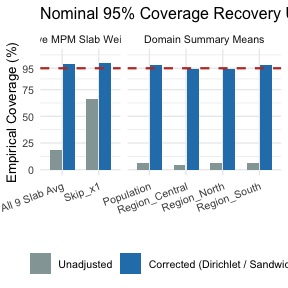

Nominal 95% Frequentist Coverage Recovery Across Both Target Classes (M = 50 Informative Replicates).

#### 3.4.1.3 Bayesian Response Imputation for Missing Outcomes ($y_i = \text{NA}$)

When survey units experience item non-response, `impute_response_lbbnn()` performs Bayesian multiple imputation via posterior predictive draws $\tilde{y}_i^{(s)} \sim \mathcal{N}(\mu_\theta(\mathbf{x}_i), \hat{\sigma}^2)$ conditioned on observed covariates $\mathbf{x}_i$. To evaluate imputation RMSE empirically against known ground truth, we randomly mask $10\%$ of observed response values in `sample_df`:

```r
# 1. Randomly mask 10% of response values to simulate item non-response
set.seed(2026)
sample_df_masked <- sample_df
n_masked <- round(0.10 * nrow(sample_df))
masked_idx <- sample(seq_len(nrow(sample_df)), size = n_masked)
true_masked_y <- sample_df$y[masked_idx]
sample_df_masked$y[masked_idx] <- NA

# 2. Perform Bayesian multiple predictive imputation
impute_out <- impute_response_lbbnn(
  object = m_weighted,
  newdata = sample_df_masked,
  target_col = "y",
  draws = 50,
  type = "predictive"
)

# 3. Compute imputation RMSE on the masked subset
imputed_y_hat <- impute_out$completed_data$y[masked_idx]
impute_rmse <- sqrt(mean((imputed_y_hat - true_masked_y)^2))

cat(sprintf("Total Masked Units: %d (10.0%% of sample)\n", n_masked))
```

```
## Total Masked Units: 74 (10.0% of sample)
```

```r
cat(sprintf("Missing Response Imputation RMSE: %.4f (Data Noise Floor sigma = 0.40)\n", impute_rmse))
```

```
## Missing Response Imputation RMSE: 0.4216 (Data Noise Floor sigma = 0.40)
```

# 4 Example 2: Two-Pass Differential Privacy Pseudo-Posterior Synthesizer

## 4.1 Simulating Skewed Sensitive Microdata

Following Savitsky, Williams & Hu (2022, Section 5 & Appendix B), financial expenditures and wages are generated from a log-normal distribution, with extreme outliers injected to represent high disclosure risk:

```r
set.seed(42)
torch::torch_manual_seed(42)
n_dp <- 300
p_dp <- 4

x_dp <- matrix(rnorm(n_dp * p_dp), nrow = n_dp, ncol = p_dp)
colnames(x_dp) <- paste0("x", 1:p_dp)

# Skewed latent process with extreme outliers
latent_mu <- 1.5 + 0.8 * x_dp[, 1] - 0.5 * x_dp[, 2]
y_dp <- exp(latent_mu + rnorm(n_dp, 0, 0.4)) # Log-normal expenditure

# Inject extreme disclosure-risk outliers on records with highest baseline predictions
outlier_idx <- order(latent_mu, decreasing = TRUE)[1:3]
y_dp[outlier_idx] <- y_dp[outlier_idx] * 8.0

# Log-transformed expenditure for Gaussian synthesizer
log_y_dp <- log(y_dp)

cat(sprintf("Dataset size: %d records\n", n_dp))
```

```
## Dataset size: 300 records
```

```r
cat(sprintf("Expenditure scale: Min=%.2f, Median=%.2f, 90th=%.2f, Max=%.2f\n",
            min(y_dp), median(y_dp), quantile(y_dp, 0.90), max(y_dp)))
```

```
## Expenditure scale: Min=0.22, Median=4.16, 90th=14.96, Max=529.57
```

```r
cat(sprintf("Log scale:         Min=%.2f, Median=%.2f, 90th=%.2f, Max=%.2f\n",
            min(log_y_dp), median(log_y_dp), quantile(log_y_dp, 0.90), max(log_y_dp)))
```

```
## Log scale:         Min=-1.52, Median=1.43, 90th=2.71, Max=6.27
```

## 4.2 Running the Two-Pass DP Synthesizer (`fit_dp_lbbnn`)

We synthesize on the properly specified log scale $\log(Y)$ using `fit_dp_lbbnn()`:

- **Pass 1**: Fits an unweighted model and automatically estimates the residual noise scale $\hat{\sigma} = \text{sd}(y - \hat{y}_{\text{p1}})$ (`sigma = NULL`).
- **Two-Stage Privacy Weights**: Evaluates record sensitivities $f_i = \max_s |L_{s, i}|$ with calibrated $\hat{\sigma}$, applies Stage 1 target ratio clipping (`stage1_method = "target_clip"`), and Stage 2 vector upward rescaling (`stage2_method = "vector_upscale"`).
- **Pass 2 / Pass 3**: Fits a model weighted by $\alpha_i$ (`normalize_weights = FALSE`), automatically executing Pass 3 to align the variational pseudo-posterior with the rescaled geometry.
- **Guarantee**: Evaluates the local Lipschitz bound $\Delta_{\alpha, \mathbf{y}} \le M_{\text{thresh}}$ and local differential privacy parameter $\epsilon_{\mathbf{y}} = 2 \Delta_{\alpha, \mathbf{y}}$.

```r
set.seed(42)
torch::torch_manual_seed(42)

spec_dp <- list(
  problem_type = "regression",
  sizes = c(p_dp, 16, 1),
  prior = c(0.5, 0.5),
  std = c(1.0, 1.0),
  inclusion_inits = "balanced",
  input_skip = TRUE,
  flow = FALSE,
  device = "cpu"
)

# Run Two-Pass Synthesizer with automatic residual scale estimation and vector upward rescaling
dp_results <- fit_dp_lbbnn(
  model_spec = spec_dp,
  X = x_dp,
  y = log_y_dp,
  epochs = 100,
  lr = 0.02,
  batch_size = 32,
  S = 50,
  stage1_method = "target_clip",
  stage2_method = "vector_upscale",
  M_thresh = 5.5,
  sigma = NULL, # Automatic residual scale calibration
  device = "cpu",
  verbose = FALSE
)

cat("Two-Pass DP Synthesis Completed!\n")
```

```
## Two-Pass DP Synthesis Completed!
```

```r
cat(sprintf("Calibrated Residual Scale (sigma_hat): %.4f\n", dp_results$sigma_hat))
```

```
## Calibrated Residual Scale (sigma_hat): 0.3591
```

```r
cat(sprintf("Pass 1 Sensitivity Range (f_i):       [%.3f, %.3f] (Median: %.3f)\n",
            min(dp_results$f_vec), max(dp_results$f_vec), median(dp_results$f_vec)))
```

```
## Pass 1 Sensitivity Range (f_i):       [0.070, 22.583] (Median: 0.966)
```

```r
cat(sprintf("Privacy Weights Range (alpha_i):      [%.3f, %.3f] (Median: %.3f, Zero count: %d)\n",
            min(dp_results$alpha), max(dp_results$alpha), median(dp_results$alpha), sum(dp_results$alpha == 0)))
```

[output not shown]

```r
cat(sprintf("Local Lipschitz Bound (Delta_alpha):  %.3f\n", dp_results$delta_alpha))
```

```
## Local Lipschitz Bound (Delta_alpha):  5.500
```

```r
cat(sprintf("Local Privacy Guarantee (Epsilon_y):  %.3f\n", dp_results$epsilon_local))
```

```
## Local Privacy Guarantee (Epsilon_y):  11.000
```

## 4.3 Inspecting Record Sensitivities & Calibrated Downweighting

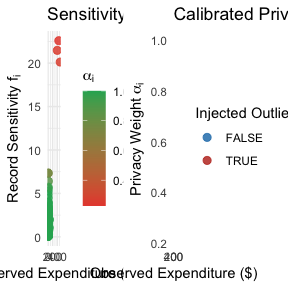

Relationship between expenditure values, record sensitivities, and calibrated privacy weights.

```r
risk_df <- data.frame(
  ObsID = seq_len(n_dp),
  Expenditure = y_dp,
  Log_Expenditure = log_y_dp,
  Sensitivity = dp_results$f_vec,
  Alpha = dp_results$alpha,
  IsOutlier = seq_len(n_dp) %in% outlier_idx
)

p1 <- ggplot(risk_df, aes(x = Expenditure, y = Sensitivity, color = Alpha)) +
  geom_point(size = 2.5, alpha = 0.85) +
  scale_color_gradient(low = "#e74c3c", high = "#27ae60", name = expression(alpha[i])) +
  theme_minimal(base_size = 11) +
  labs(
    title = "Sensitivity vs. Expenditure",
    x = "Observed Expenditure ($)",
    y = expression("Record Sensitivity " * f[i])
  )

p2 <- ggplot(risk_df, aes(x = Expenditure, y = Alpha, color = IsOutlier)) +
  geom_point(size = 2.5, alpha = 0.85) +
  scale_color_manual(values = c("FALSE" = "#2980b9", "TRUE" = "#c0392b"), name = "Injected Outlier") +
  theme_minimal(base_size = 11) +
  labs(
    title = "Calibrated Privacy Weights",
    x = "Observed Expenditure ($)",
    y = expression("Privacy Weight " * alpha[i])
  )

gridExtra::grid.arrange(p1, p2, ncol = 2)
```

The calibrated two-stage construction performs cleanly:

### 4.3.1 Full Factorial Comparison of Privacy Calibration Schemes (Savitsky, Oct 29, 2026)

To understand how each Stage 1 normalization and Stage 2 reweighting strategy behaves on this sensitive expenditure dataset ($n = 300$), we evaluate the full $3 \times 2$ factorial grid across Stage 1 (`target_clip`, `linear`, `percentile`) $\times$ Stage 2 (`vector_upscale`, `hard_trunc`) plus the `reciprocal_linear` baseline (Savitsky, 2026, Remark 1) using `compute_dp_weights()` at $M_{\text{thresh}} = 5.5$:

```r
f_curr <- dp_results$f_vec
M_curr <- 5.5

sch_tc_vec  <- compute_dp_weights(f_curr, stage1_method = "target_clip", stage2_method = "vector_upscale",
                                   Delta_goal = M_curr, M_thresh = M_curr)
sch_tc_hard <- compute_dp_weights(f_curr, stage1_method = "target_clip", stage2_method = "hard_trunc",
                                   Delta_goal = M_curr, M_thresh = M_curr)
sch_lin_vec <- compute_dp_weights(f_curr, stage1_method = "linear", stage2_method = "vector_upscale",
                                   c_scale = 0.85, M_thresh = M_curr)
sch_lin_hard <- compute_dp_weights(f_curr, stage1_method = "linear", stage2_method = "hard_trunc",
                                    c_scale = 0.85, M_thresh = M_curr)
sch_pct_vec <- compute_dp_weights(f_curr, stage1_method = "percentile", stage2_method = "vector_upscale",
                                   M_thresh = M_curr)
sch_pct_hard <- compute_dp_weights(f_curr, stage1_method = "percentile", stage2_method = "hard_trunc",
                                    M_thresh = M_curr)
sch_recip_hard <- compute_dp_weights(f_curr, stage1_method = "reciprocal_linear", stage2_method = "hard_trunc",
                                      c_scale = 0.85, M_thresh = M_curr)

comp_df <- data.frame(
  `Stage 1 Method` = c("target_clip", "target_clip", "linear (c=0.85)", "linear (c=0.85)",
                       "percentile (p=0.05, 0.95)", "percentile (p=0.05, 0.95)",
                       "reciprocal_linear (Remark 1)"),
  `Stage 2 Method` = c("vector_upscale", "hard_trunc", "vector_upscale", "hard_trunc",
                       "vector_upscale", "hard_trunc", "hard_trunc"),
  `Effective N (sum alpha)` = c(round(sum(sch_tc_vec$alpha), 1), round(sum(sch_tc_hard$alpha), 1),
                                round(sum(sch_lin_vec$alpha), 1), round(sum(sch_lin_hard$alpha), 1),
                                round(sum(sch_pct_vec$alpha), 1), round(sum(sch_pct_hard$alpha), 1),
                                round(sum(sch_recip_hard$alpha), 1)),
  `Full Weight (alpha=1)` = c(sprintf("%.1f%%", 100 * mean(sch_tc_vec$alpha >= 0.999)),
                              sprintf("%.1f%%", 100 * mean(sch_tc_hard$alpha >= 0.999)),
                              sprintf("%.1f%%", 100 * mean(sch_lin_vec$alpha >= 0.999)),
                              sprintf("%.1f%%", 100 * mean(sch_lin_hard$alpha >= 0.999)),
                              sprintf("%.1f%%", 100 * mean(sch_pct_vec$alpha >= 0.999)),
                              sprintf("%.1f%%", 100 * mean(sch_pct_hard$alpha >= 0.999)),
                              sprintf("%.1f%%", 100 * mean(sch_recip_hard$alpha >= 0.999))),
  `Zeroed (alpha=0)` = c(sum(sch_tc_vec$alpha == 0), sum(sch_tc_hard$alpha == 0),
                         sum(sch_lin_vec$alpha == 0), sum(sch_lin_hard$alpha == 0),
                         sum(sch_pct_vec$alpha == 0), sum(sch_pct_hard$alpha == 0),
                         sum(sch_recip_hard$alpha == 0)),
  `Realized Delta` = c(round(sch_tc_vec$delta_alpha, 2), round(sch_tc_hard$delta_alpha, 2),
                       round(sch_lin_vec$delta_alpha, 2), round(sch_lin_hard$delta_alpha, 2),
                       round(sch_pct_vec$delta_alpha, 2), round(sch_pct_hard$delta_alpha, 2),
                       round(sch_recip_hard$delta_alpha, 2)),
  `Local Epsilon` = c(round(sch_tc_vec$epsilon_local, 2), round(sch_tc_hard$epsilon_local, 2),
                      round(sch_lin_vec$epsilon_local, 2), round(sch_lin_hard$epsilon_local, 2),
                      round(sch_pct_vec$epsilon_local, 2), round(sch_pct_hard$epsilon_local, 2),
                      round(sch_recip_hard$epsilon_local, 2)),
  check.names = FALSE
)

knitr::kable(
  comp_df,
  caption = "Full 3 x 2 Factorial + Reciprocal Benchmark of Stage 1 Normalization and Stage 2 Reweighting on n = 300 (Savitsky, Oct 29, 2026)"
)
```

Full 3 x 2 Factorial + Reciprocal Benchmark of Stage 1 Normalization and Stage 2 Reweighting on n = 300 (Savitsky, Oct 29, 2026)

| Stage 1 Method | Stage 2 Method | Effective N (sum alpha) | Full Weight (alpha=1) | Zeroed (alpha=0) | Realized Delta | Local Epsilon |
| --- | --- | --- | --- | --- | --- | --- |
| target_clip | vector_upscale | 297.1 | 97.3% | 0 | 5.50 | 11.00 |
| target_clip | hard_trunc | 297.1 | 97.3% | 0 | 5.50 | 11.00 |
| linear (c=0.85) | vector_upscale | 296.8 | 97.3% | 1 | 5.50 | 11.00 |
| linear (c=0.85) | hard_trunc | 238.7 | 0.0% | 1 | 4.23 | 8.46 |
| percentile (p=0.05, 0.95) | vector_upscale | 285.0 | 95.0% | 15 | 3.46 | 6.92 |
| percentile (p=0.05, 0.95) | hard_trunc | 199.9 | 5.7% | 15 | 0.91 | 1.82 |
| reciprocal_linear (Remark 1) | hard_trunc | 30.9 | 0.0% | 1 | 0.06 | 0.12 |

### 4.3.2 Finite-Sample $(\epsilon, \delta)$-DP Guarantee & Additive Nugget $\eta$ Calibration (`calibrate_dp_finite_sample`)

As established by **Azizi, Savitsky, Williams & Chatterjee (Nov 2026)** (*Algorithm 3.1 / Section 3.2*), the unadjusted local privacy parameter $\epsilon_{\mathbf{x}} = 2\Delta_{\alpha, \mathbf{x}}$ relies on an asymptotic concentration assumption and exhibits a non-negligible finite-sample exceedance probability $\hat{\delta}_n(0) = \mathbb{P}_{\mathbf{x}_r}(\Delta_{\alpha, \mathbf{x}_r} > \Delta_{\alpha, \mathbf{x}}) > 0$ under posterior predictive resampling. Explicitly, **Fred Azizi** et al. show that evaluating these replicates via **dual-support plug-in with zero additional neural network training** avoids costly repeated model refitting:

1. Freeze $B = 100$ posterior draws from the Pass 1 unweighted generator ($\Theta^{(1)}$) via `extract_lbbnn_support()` and from the Pass 2/3 weighted synthesizer ($\Theta_\alpha^{(2)}$).
2. Generate $R = 200$ posterior predictive replicate response vectors $\mathbf{x}_r \sim p_{\Theta^{(1)}}(\cdot \mid \mathbf{X})$.
3. **Stage 1 Plug-in**: Evaluate replicate log-likelihoods on $\Theta^{(1)}$ (`eval_support_abs_loglik()`) to obtain replicate sensitivities $\mathbf{f}(\mathbf{x}_r)$ and risk-calibrated weights $\boldsymbol{\alpha}(\mathbf{x}_r)$ without fitting a new neural network.
4. **Stage 2 Re-plug**: Evaluate replicate weighted sensitivities $\Delta_{\alpha, \mathbf{x}_r} = \max_{b,i} \alpha_i(\mathbf{x}_r) |\log p_{\theta_b^{(2)}}(x_{r,i})|$ on $\Theta_\alpha^{(2)}$, quantify unadjusted leakage $\hat{\delta}_n(0)$, and solve for the minimal additive calibration nugget $\eta = \max\{0,\, q_{1-\delta_{\text{target}}}(\{\Delta_{\alpha,\mathbf{x}_r}\}) - \Delta_{\alpha,\mathbf{x}}\}$ delivering finite-sample $(\epsilon_{\mathbf{x}}(\eta), \delta_{\text{target}})$-DP with $\epsilon_{\mathbf{x}}(\eta) = 2(\Delta_{\alpha,\mathbf{x}} + \eta)$.

```r
dp_cal <- calibrate_dp_finite_sample(
  dp_fit       = dp_results,
  X            = x_dp,
  y            = log_y_dp,
  R            = 200,
  B            = 100,
  delta_target = c(0.10, 0.05, 0.01),
  seed         = 2026
)

knitr::kable(
  dp_cal$calibration_table,
  digits    = 4,
  row.names = FALSE,
  col.names = c(
    "Target delta", "1-delta Quantile", "Nugget eta",
    "Delta + eta", "Calibrated eps", "Empirical Exceed"
  ),
  caption   = sprintf(
    "Finite-Sample (eps, delta)-DP Calibration (Obs Delta = %.4f, delta(0) = %.3f)",
    dp_cal$delta_alpha_obs, dp_cal$delta_hat_0
  )
)
```

Finite-Sample (eps, delta)-DP Calibration (Obs Delta = 5.5000, delta(0) = 0.515)

| Target delta | 1-delta Quantile | Nugget eta | Delta + eta | Calibrated eps | Empirical Exceed |
| --- | --- | --- | --- | --- | --- |
| 0.10 | 6.9332 | 1.4332 | 6.9332 | 13.8665 | 0.10 |
| 0.05 | 7.1573 | 1.6573 | 7.1573 | 14.3145 | 0.05 |
| 0.01 | 7.3765 | 1.8765 | 7.3765 | 14.7531 | 0.01 |

[figure not shown]

Dual-Support Plug-In Replicate Sensitivity Distribution (R = 200, Zero Retraining).

## 4.4 Generating and Benchmarking Synthetic Datasets

Sampling from the **posterior predictive distribution** incorporates parameter uncertainty and residual observation noise:

$$y_i^{\text{synth}} \sim
\mathcal{N}\big(\mu_\theta(\mathbf{x}_i), \hat{\sigma}^2\big), \quad
Y_i^{\text{synth}} = \exp\big(y_i^{\text{synth}}\big)$$

```r
# Non-private baseline synthesizer wrapper
nonprivate_fit <- list(model = dp_results$model_unweighted, sigma_hat = if (!is.null(dp_results$sigma_pass1)) dp_results$sigma_pass1 else dp_results$sigma_hat)

# Draw 20 synthetic replicate datasets of size n = 300
synth_mat_nonprivate <- sample_synthetic_lbbnn(nonprivate_fit, newdata = x_dp, draws = 20, log_scale = TRUE)
synth_mat_private    <- sample_synthetic_lbbnn(dp_results, newdata = x_dp, draws = 20, log_scale = TRUE)

calc_synth_stats <- function(mat) {
  rowMeans(apply(mat, 2, function(col) {
    c(mean(col), sd(col), quantile(col, 0.25), median(col),
      quantile(col, 0.75), quantile(col, 0.90), max(col))
  }))
}

clean_y <- y_dp[-outlier_idx]
clean_stats <- c(mean(clean_y), sd(clean_y), quantile(clean_y, 0.25), median(clean_y),
                 quantile(clean_y, 0.75), quantile(clean_y, 0.90), max(clean_y))
orig_stats <- c(mean(y_dp), sd(y_dp), quantile(y_dp, 0.25), median(y_dp),
                quantile(y_dp, 0.75), quantile(y_dp, 0.90), max(y_dp))
nonpriv_stats <- calc_synth_stats(synth_mat_nonprivate)
priv_stats    <- calc_synth_stats(synth_mat_private)

# Distributional Benchmark Table on Expenditure Scale ($)
bench_df <- data.frame(
  Metric = c("Mean", "Std. Dev.", "25th Pct", "Median", "75th Pct", "90th Pct", "Max (Extreme)"),
  Original_Clean = clean_stats,
  Original_With_Outliers = orig_stats,
  NonPrivate_Synthetic = nonpriv_stats,
  DP_Private_Synthetic = priv_stats,
  row.names = NULL
)

knitr::kable(
  bench_df,
  digits = 2,
  row.names = FALSE,
  col.names = c("Metric", "Original (Clean)", "Original (With Outliers)", "Non-Private Synthetic", "DP-Private Synthetic"),
  caption = "Distributional Utility Comparison: Original (Clean vs. Outlier-Contaminated) and Synthetic Microdata (Averaged Across 20 Replicates)"
)
```

Distributional Utility Comparison: Original (Clean vs. Outlier-Contaminated) and Synthetic Microdata (Averaged Across 20 Replicates)

| Metric | Original (Clean) | Original (With Outliers) | Non-Private Synthetic | DP-Private Synthetic |
| --- | --- | --- | --- | --- |
| Mean | 6.70 | 11.30 | 7.99 | 7.68 |
| Std. Dev. | 7.23 | 46.75 | 11.20 | 9.56 |
| 25th Pct | 2.20 | 2.22 | 2.15 | 2.24 |
| Median | 4.10 | 4.16 | 4.54 | 4.65 |
| 75th Pct | 9.09 | 9.31 | 9.62 | 9.43 |
| 90th Pct | 14.40 | 14.96 | 18.09 | 16.72 |
| Max (Extreme) | 62.54 | 529.57 | 108.71 | 83.01 |

The benchmark table demonstrates the utility and privacy advantages of the two-pass synthesizer:

- In the raw data, the 3 extreme outliers (`Max = $529.57`) distort the sample mean (`$11.30` vs. `$6.70` clean) and explode the sample standard deviation (`$46.75` vs. `$7.23` clean).
- The `DP-Private Synthetic` data closely matches the **clean population distribution** across the mean (`$7.68`), standard deviation (`$9.56`), median (`$4.65`), and 90th percentile (`$16.72`), while completely eliminating the extreme `$529.57` outlier disclosure risk.

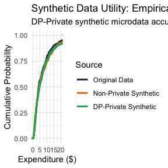

Empirical Cumulative Distribution Functions (ECDF) showing close utility preservation across the population body while protecting extreme outlier records.

```r
ecdf_df <- data.frame(
  Value = c(y_dp, synth_mat_nonprivate[, 1], synth_mat_private[, 1]),
  Source = factor(c(
    rep("Original Data", n_dp),
    rep("Non-Private Synthetic", n_dp),
    rep("DP-Private Synthetic", n_dp)
  ), levels = c("Original Data", "Non-Private Synthetic", "DP-Private Synthetic"))
)

ggplot(ecdf_df, aes(x = Value, color = Source)) +
  stat_ecdf(geom = "step", size = 1.1) +
  coord_cartesian(xlim = c(0, quantile(y_dp, 0.95))) +
  scale_color_manual(values = c(
    "Original Data" = "#2c3e50",
    "Non-Private Synthetic" = "#e67e22",
    "DP-Private Synthetic" = "#27ae60"
  )) +
  theme_minimal(base_size = 11) +
  labs(
    title = "Synthetic Data Utility: Empirical CDF",
    subtitle = "DP-Private synthetic microdata accurately reproduces the body of the true distribution",
    x = "Expenditure ($)",
    y = "Cumulative Probability"
  )
```